# Landing page

# Decoding Song Success: Predicting Song Popularity - an NLP Approach

## Key Topics

Music, Lyrics, Hot 100 chart, hit songs, popular music research, Natural Language Processing, Supervised Machine Learning, Unsupervised Machine Learning, Sentiment Analysis

## Project Introduction

Decoding Song Success uses data science to uncover insights from the Rolling Stones Top 100 Songs. We bridged NLP and song metadata to analyze features like the characteristics of the lyrics of hits by running sentiment analysis, the popularity of the song, the popularity of the artist, and the genre. We hope to investigate how these features interact to shape the top hits. This website offers a data driven report, informative visualizations, and predictive models to convey the makings of a hit song.

### Motivation

Music is an important part of popular culture with implications in everything from social contexts to consumerism. What makes a song a hit lies in complex emotional and commercial relationships. Analyzing the data about the songs that are considered successful can reveal connections between the lyrical sentiment, the song’s characteristics, and audience preferences. This project highlights these patterns to help inform rising artists and predict commerciall success in the music industry. Some use cases of this analysis include helping songwriters decide whether explicit songs differ significantly from not explicit songs, cluster songs by features to offer recommendations, and help industry professionals predict whether a song will be a hit as they make investment decisions.

### Data Science Question

The overall driving question of this exploration is as follows:

What makes a song more popular with audiences, and how do lyrical and musical factors shape its success?

### Research Questions

As we conducted our investigation of music data, we aimed to answer the following questions:

1. How does lyric sentiment influence a song’s popularity? Do other lyric features (such as length) have an influence?
2. Does lyric sentiment differ across genres, and does the trend between sentiment and popularity change between genres?
3. How does profanity in a song impact it’s sentiment and popularity?
4. Can we use unsupervised learning techniques to identify clusters and create playlists of songs that someone may like based on liking a hit song?
5. Does collaboration between artists produce more popular songs? How does individual artist popularity impact this?

### Conclusion

This project provides an in-depth study of the connection between data science and music. As you explore the visualizations, predictive models, and business report, we hop you learn more about what makes a song a hit!

## About the Authors

### Satomi Ito

#### Professional Overview

Hello! I’m **Satomi Ito**, an aspiring data scientist with a passion for making data-driven decisions. I am currently a Data Science Master’s student at Georgetown University, where I explore the intersection of data-driven insights and impactful solutions.

#### Skills and Expertise

- **Programming Languages**: Python, R, MATLAB, SQL
- **Technical Competencies**: Predictive Modeling, Statistical Analysis, Data Visualization
- My background in **Cognitive Science** equips me with a multidisciplinary approach to technical development, blending human understanding and machine learning.

#### Professional Journey

My professional journey began with a Bachelor’s degree in **Cognitive Science** at the **University of California, San Diego**, where I developed a deep interest in understanding complex systems and patterns.

- After graduation, I took a year working in research. During my time at a neurology research lab at Zuckerberg General Hospital, I worked on developing **predictive models** to analyze and interpret neurological data. This experience honed my technical skills and reinforced my passion for solving real-world problems using data.

#### Work Philosophy

I approach challenges with a problem-solving mindset, leveraging data to uncover actionable insights. I enjoy collaboration and think that it’s an impact way to grow and learn.

#### Educational Background

- **M.S. in Data Science and Analytics**, Georgetown University (Current)
- **B.S. in Cognitive Science**, University of California, San Diego 2019 - 2023

#### Personal Interests

Outside of my academic and professional work, I enjoy: - **Climbing**: Rope and bouldering - **DIY Projects**: I am currently building a shelf from scratch.

- **LinkedIn**: [Satomi Ito](https://www.linkedin.com/in/satomitheito/)
- **GitHub**: satomitheito

### Samyu Vakkalanka

#### Professional Overview

Welcome to our site! My name is Samyukta (Samyu) Vakkalanka. I am a first year master’s student in the Data Science and Analytics program at Georgetown University. I have experience in government research applying machine learning to cybersecurity and in business intelligence working in marketing analysis. I am interested in academic research in data science, especially as it relates to sustainibility and climate studies.

#### Skills and Expertise

- **Programming Languages**: Python, R, MATLAB, HTML/CSS/JavaScript, Java, SQL
- **Technical Competencies**: Machine Learning, Natural Language Processing, Data Visualization, Statistics, Applied Mathematics
- My background in mathematics and statistics uniquely allows me to approach data science problems with a strong foundation in theory, enabling me to develop robust models, apply advanced statistical methodologies, and extract meaningful insights from complex datasets.

#### Professional Journey

My professional journey began with my undergraduate degrees from the University of Southern California. I studied Data Science and Applied and Computational Mathematics, where I developed a passion for bridging theoretical statistics and the real world applications of data science.

During my time at USC, I completed an internship at Lawrence Livermore National Laboratory. My work consisted of developing novel statistical models and machine learning applications to study industrial control system networks and isolate suspicious behavior. I then worked at Comcast with the marketing and sales channel analytics teams. Here, I used supervised ML models to understand the variance in regions of churn and penetration. I directly continued into my Master’s program, where I now work in the AI Measurement and Development lab studying student computational skills and attention using eye tracking technology.

#### Work Philosophy

My approach to work combines attention to detail, creativity, and adaptability. I believe breaking down problems into manageable steps is extremely important and allows me to get feedback at every step. I have a strong focus on collaboration and strong communication, where I tailor my presentation of my work for the audience that I am working with.

#### Educational Background

- **M.S. in Data Science and Analytics**, Georgetown University 2024 - 2026 (expected)
- **B.A. in Data Science**, University of Southern California 2020 - 2024
- **B.A. in Applied and Computational Mathematics**, University of Southern California 2020 - 2024

#### Achievements and Recognitions

- Merit Scholarship Award Recipient - Georgetown University 2024-2025
- Athena Hacks Winner - Best Use of Google Cloud 2023
- Google Cloud Student Innovator - 2023-2024
- National Merit Scholarship Finalist and Presidential Scholarship Recipient - 2020-2024

#### Personal Interests

Outside of my academic and professional work, I enjoy: - **Music**: I have played the piano and violin for 10+ years - **Baking**: I believe I have officially perfected the art of the chocolate chip cookie (thin, salted, and crispy is the way to go!)

#### Reach out to me!

- **LinkedIn**: [Samyukta Vakkalanka](https://www.linkedin.com/in/samyukta-vakkalanka/)
- **GitHub**: samyu-vakkalanka

## Literature review

To conduct this literature review, we decided to split articles into two categories: research about the musicality of songs in top charts and papers about the lyrics of songs in top charts. While the first topic has a wide range of approaches, studies related to the lyrics are far rarer. 3 articles were found for each category and the results are reported below.

### Musicality

#### Musical trends and predictability of success in contemporary songs in and out of the top charts<sup>1</sup>

In this research article, Interiano et al. uses random forest models to predict whether a song would “make it to the charts” using acoustic features such as mood, danceability, relaxedness, and frequency of male/female singers contributing to the song. They highlighted the trend that songs with fewer male contributors, instrumentals that are considered more “dance-based” music, and brighter sounding songs are strong indicators of the success of a song. The graph below shows this trend over time, with the red dots being songs that are not in the top 100 and blue dots being songs that are in the top 100.

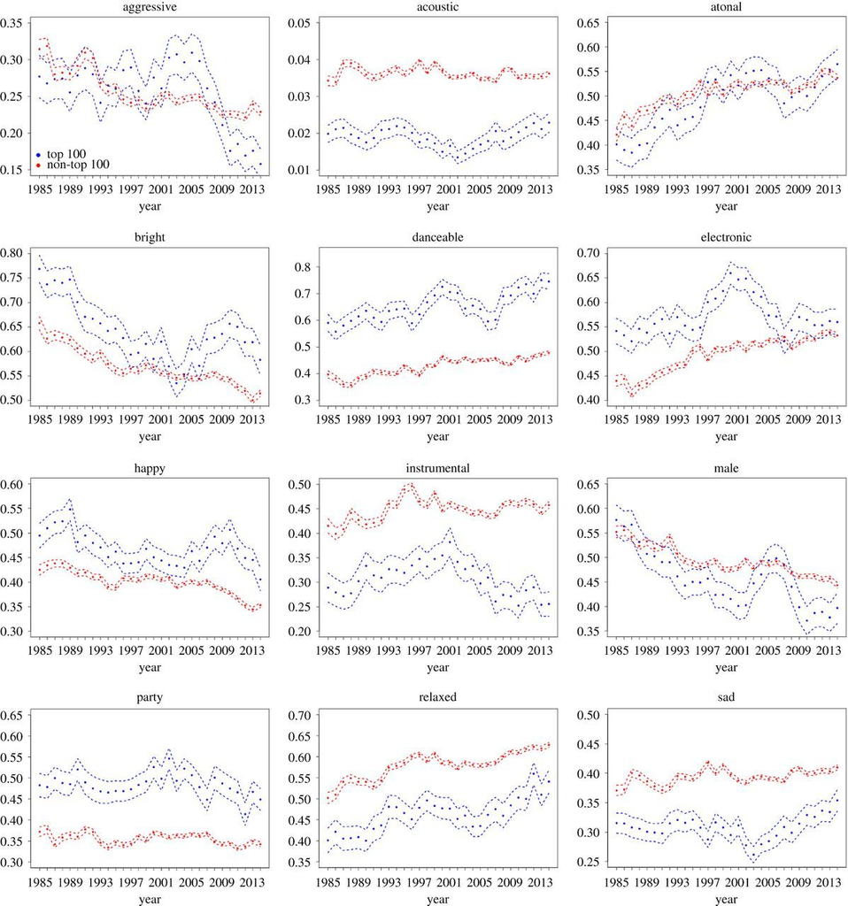

Source 1 Results

#### Sustainable success in the music industry: Empirical analysis of music preferences<sup>2</sup>

Kim et al. developed a hierarchical Bayesian logit choice model that takes into account features of the instrumentals of a range of hit songs (such as melody, tempo, harmony, and rhythm) to determine the consumer preference for a specific song. The data was collected through controlled lab tests. They then tried to correlate the resulting preferences to the profits of a song by considering music development costs. Overall, they found that consonant harmony, piano, slow tempo, and irregular rhythm to be more desirable by consumers and to be the most monetarily sustainable choices to include in a song.

#### A comment on survival of the hippest: life at the top of the hot 100<sup>3</sup>

Hong analyzed songs that have hit the number 1 spot from 1955 to 2003 and used features such as gender, number, and race of the singers of the song to analyze if artist characteristics contributed to the long-term success of a song (i.e. number of weeks that the song would be at the top of the charts). They used parametric estimation of a log-logistic distribution to find that the presence of Black artists contributed to longer runs at the top of the chart (which they contribute to the success of rap songs). They also concluded that, in groups, the gender of the members of the groups did not actually contribute to the song’s success.

### Lyrics

#### The Language of Lyrics: An Analysis of Popular Billboard Songs Across Conditions of Social and Economic Threat<sup>4</sup>

Pettijohn et al. conducted an analysis on the changes in the subjects of the lyrics of Billboard number 1 songs between 1955-2003 using the LIWC program for NLP which produces a series of psychometric features of songs, such as a focus on the future, meaningfulness, comfort, and romance. They then correlated this with US economic conditions collected from various psychology studies regarding the social reaction to US presidents and politics. In the end, they found that songs that were more romantic and comforting, as well as songs with more words per sentence and more mentions of social processes were more common during years that they considered to have more “threatening” conditions.

#### The power of repetition: repetitive lyrics in a song increase processing fluency and drive market success<sup>5</sup>

Study 3 in the paper by Nunes et al. considered songs from Billboard’s top 100 singles between 1958-2012 and studied how repetitive they are (such as how many times the chorus is repeated). They determined that more repetitive lyrics correlate strongly with the position at which a song debuts (top 40 or not) and how many weeks it takes for the song to reach the number 1 spot. This understanding of the structure of lyrics is a novel approach to studying the popularity of music and informed some of the questions we asked about our dataset.

#### An Analysis of Common Songwriting and Production Practices in 2014-2015 Billboard Hot 100 Songs<sup>6</sup>

This report by Tough introduces a new set of features regarding the songwriting procedures of Billboard Hot 100 songs between 2014-2015, including repeating the title in the song, intro length, the presence of archetypes (i.e. the Innocent, the Lover, the Everyman, the Ruler), and song subject. The results include showing that a song in the top 100 is more likely to have an 11-15 second intro, start with a chorus or hook, and have the lover archetype (followed by the warrior archetype). They also find that specific combinations of archetypes (including the warrior/ruler pairing) are more common in the top 100 songs. The below charts show some of these results.

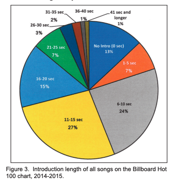

Source 6 Results - Intro Length

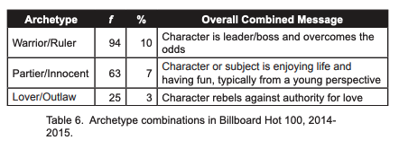

## References

1.

Interiano, M. *et al.* [Musical trends and predictability of success in contemporary songs in and out of the top charts](https://doi.org/10.1098/rsos.171274). *Royal Society Open Science* **5**, 171274 (2018).

2.

Kim, J. & Kang, M. Y. [Sustainable success in the music industry: Empirical analysis of music preferences](https://doi.org/10.1016/j.jbusres.2022.01.021). *Journal of Business Research* **142**, 1068–1076 (2022).

3.

Giles, D. E. [Survival of the hippest: Life at the top of the hot 100](https://doi.org/10.1080/00036840600707159). *Applied Economics* **39**, 1877–1887 (2007).

4.

Pettijohn, T. F. & Sacco, D. F. [The language of lyrics: An analysis of popular billboard songs across conditions of social and economic threat](https://doi.org/10.1177/0261927X09335259). *Journal of Language and Social Psychology* **28**, 297–311 (2009).

5.

Nunes, J. C., Ordanini, A. & Valsesia, F. [The power of repetition: Repetitive lyrics in a song increase processing fluency and drive market success](https://doi.org/10.1016/j.jcps.2014.12.004). *Journal of Consumer Psychology* **25**, 187–199 (2015).

6.

Tough, D. [An analysis of common songwriting and production practices in 2014-2015 billboard hot 100 songs](https://doi.org/10.25101/17.4). *Journal of the Music and Entertainment Industry Educators Association* **17**, 79–120 (2017).